# Figure S8

John Favate

2020-12-21 10:14:43

```r
# Prevent printing of warnings and such in the HTML
knitr::opts_chunk$set(warning = FALSE, message = FALSE, fig.align = "center")
```

```r
library(tidyverse)
library(patchwork)
library(gridExtra)
library(grid)
library(corrr)
library(ggpubr)

pps.df <- read_csv("../../data_frames/table_s12_pps_scores.csv")

kegg.df <- read_csv("../../data_frames/table_s11_kegg_results.csv")

all.data <- read_csv("../../data_frames/all_data.csv")
```

This figure is for the first section functional analysis

mutator order and colors

```r
mut.levels <- all.data %>%
  select(line, mutator) %>%
  arrange(mutator, line) %>%
  unique() %>%
  pull(line)

mut.colors <- c("black", rep("black", 5), rep("firebrick3", 5))
```

### Panel A

```r
sig.terms <- kegg.df %>%
  filter(seqtype == "ribo") %>%
  filter(qvalues <= .05) %>%
  group_by(description) %>%
  tally() %>%
  ungroup() %>%
  filter(n >= 4 & !is.na(description)) %>%
  pull(description)
```

Order the terms by mean enrichment score across the lines, this makes an ordered vector where the ends are the top up and down pathways.

```r
# decide the order
term.order <- kegg.df %>%
  filter(description %in% sig.terms) %>%
  group_by(description, seqtype) %>%
  summarise(mean.es = mean(enrichmentscore)) %>%
  filter(seqtype == "ribo") %>%
  arrange(mean.es) %>%
  pull(description)

# get the top terms
top.terms <- c(head(term.order, 6), tail(term.order, 6))
```

Factor the data frame by various metrics to enforce axis order.

```r
kegg.df$description <- factor(kegg.df$description, levels = rev(term.order))

kegg.df$line <- factor(kegg.df$line, levels = mut.levels)

kegg.df$seqtype <- factor(kegg.df$seqtype, levels= c("rna", "ribo"))
```

Plot

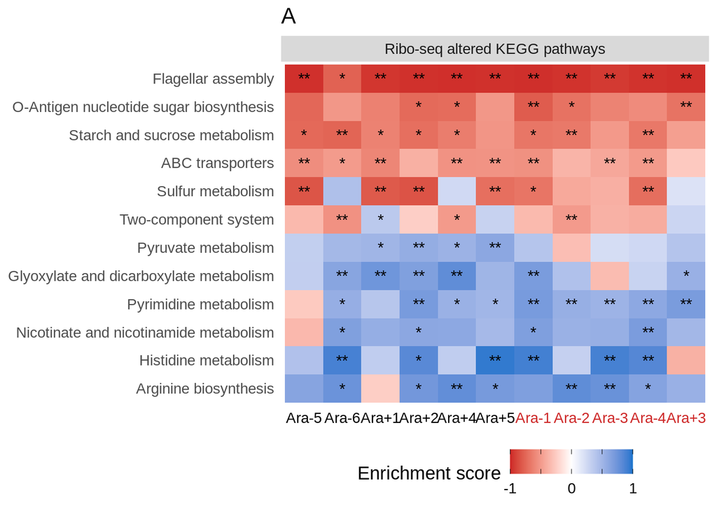

```r
fac.labs <- c("rna" = "RNA-seq altered KEGG pathways", "ribo" = "Ribo-seq altered KEGG pathways")

pa <- kegg.df %>%
  filter(description %in% top.terms & seqtype == "ribo") %>%
  mutate(sigstar = ifelse(qvalues <= .01, "**", ifelse(qvalues <= .05, "*", ""))) %>%
  ggplot(., aes(line, description, fill = enrichmentscore, label = sigstar))+
  geom_raster()+
  scale_fill_gradientn(name = "Enrichment score",
                       colors = c("firebrick3", "white", "dodgerblue3"),
                       breaks = seq(-1, 1, .5),
                       labels = c(-1, "", 0, "", 1),
                       limits = c(-1, 1),
                       guide = guide_colorbar(ticks.colour = "black"))+
  geom_text()+
  theme(legend.position = "bottom")+
  labs(x = NULL, y = NULL, title = "A")+
  theme(panel.background = element_blank(),
        axis.ticks = element_blank(),
        text = element_text(size = 13),
        axis.text.x = element_text(color = mut.colors))+
  facet_wrap(~ seqtype, labeller = as_labeller(fac.labs))+
  scale_y_discrete(labels = scales::label_wrap(width = 40))

pa
```

### Panel B

Remove some odd characters

```r
pps.df$common_name <- gsub("<i>N<\\/i>", "N", pps.df$common_name) %>%
  gsub("<i>O<\\/i>", "O", .) %>%
  gsub("(<i>E. coli<\\/i>)", "", .) %>%
  gsub("\\(\\)", "", .)
```

Determine the top the top n pathways by looking at mean PPS across lines

```r
path.order <- pps.df %>%
  filter(type == "actual" & seqtype == "ribo") %>% # only the actual PPS for RNAseq
  group_by(common_name) %>%                        # for each pathway
  summarise(mean_pps = mean(pps)) %>%              # calc mean pps
  ungroup() %>%                                    #
  arrange(desc(mean_pps)) %>%                      # order pathways by decreasing PPS
  pull(common_name)                                # get pathway identifier
```

Pick the top n pathways to display and create a data frame for graphing

```r
tops <- path.order[1:10]

bdf <- pps.df %>%
  filter(seqtype == "ribo" & type == "actual" & common_name %in% tops) %>% # pick those top pathways for RNAseq
  mutate(common_name = factor(common_name, levels = tops))                 # factor so they appear in order of inc PPS

head(bdf)
```

| seqtype | line | pathway | pps | type | iteration | common_name |
| --- | --- | --- | --- | --- | --- | --- |
| ribo | Ara+2 | PWY-5340 | 8.540354 | actual | real | sulfate activation for sulfonation |
| ribo | Ara-5 | PWY-5340 | 8.502615 | actual | real | sulfate activation for sulfonation |
| ribo | Ara+2 | PWY-6772 | 7.315855 | actual | real | hydrogen production V |
| ribo | Ara+2 | SO4ASSIM-PWY | 6.526023 | actual | real | sulfate reduction I (assimilatory) |
| ribo | Ara-5 | SO4ASSIM-PWY | 6.140349 | actual | real | sulfate reduction I (assimilatory) |
| ribo | Ara+3 | PWY-6772 | 5.393590 | actual | real | hydrogen production V |

Graph them

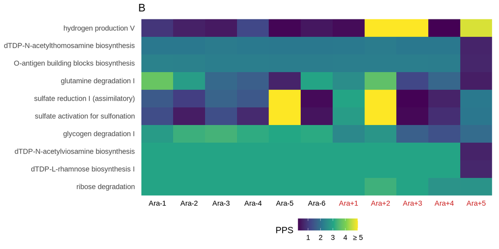

```r
b.labs <- c("0", "1", "2", "3", "4", paste("\u2265", 5))

pb <- bdf %>%
  mutate(newpps = ifelse(pps > 5, 5, pps)) %>%
  ggplot(., aes(line, common_name, fill = newpps))+
  geom_raster()+
  theme(legend.position = "bottom")+
  labs(x = NULL, y = NULL, title = "B")+
  theme(panel.background = element_blank(),
        axis.ticks = element_blank(),
        text = element_text(size = 13),
        axis.text.x = element_text(color = mut.colors))+
  scale_fill_viridis_c(option = "D", name = "PPS", labels = b.labs)+
  scale_y_discrete(labels = scales::label_wrap(width = 40))

pb
```

### Panel C

Correlation of RNA_seq and Ribo-seq PPS scores as well as correlation of KEGG RNA-seq and Ribo-seq enrichment scores. This shows that the riboseq and RNAseq data say the same thing. Compare RNAseq/riboseq PPS.

```r
pps.rna.ribo.cors <- pps.df %>%                            #
  filter(type == "actual") %>%                             # keep actual PPS, not randomized
  select(pathway, line, pps, seqtype) %>%                  # retain these cols
  pivot_wider(names_from = seqtype, values_from = pps) %>% # reshape each seqtype has its own col
  split(.$line) %>%                                        # for each line
  map(function(x){                                         # compare the rna/ribo scores
    x %>%                                                  #
      select(-line, -pathway) %>%                          # remove these cols
      corrr::correlate(method = "spearman") %>%            # compare the RNAseq and riboseq cors
      .[2,2]                                               # pick the correlation, the others are redundancies
  }) %>%                                                   #
  bind_rows(.id ="line") %>%                               # recombine the data
  mutate(type = "PPS") %>%                                 # add a col that will differentiate from kegg
  dplyr::rename("rs" = "rna")                              #
```

Do the same for the kegg.

```r
kegg.rna.ribo.cors <- kegg.df %>%                                      #
  filter(description %in% sig.terms) %>%                               # consider all significant terms in any line
  select(line, seqtype, id, enrichmentscore) %>%                       # retain these cols
  pivot_wider(names_from = seqtype, values_from = enrichmentscore) %>% # reshape to rna/ribo cols
  split(.$line) %>%                                                    # for each line
  map(function(x){                                                     # compare the rna/ribo scores
    x %>%                                                              #
      select(-line, -id) %>%                                           # remove these cols
      corrr::correlate(method = "spearman") %>%                        # correlate
      .[2,2]                                                           # pick the cor, the other are redundant
  }) %>%                                                               #
  bind_rows(.id ="line") %>%                                           # recombine the lines
  mutate(type = "Enrichment score") %>%                                # label to differentiate from pps
  dplyr::rename("rs" = "ribo")                                         # rename that col
```

A plot of those

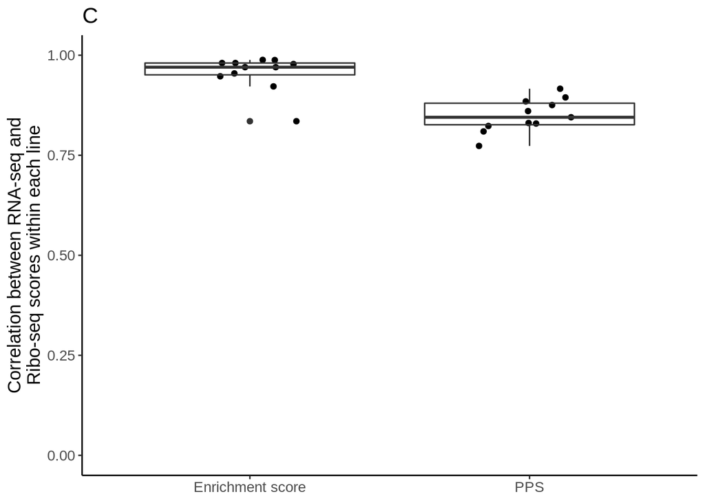

```r
pc <- bind_rows(kegg.rna.ribo.cors, pps.rna.ribo.cors) %>%
  ggplot(., aes(type, rs))+
  geom_jitter(height = 0, width = .2)+
  geom_boxplot(fill = NA)+
  scale_y_continuous(limits = c(0,1))+
  theme_classic()+
  theme(text = element_text(size = 13))+
  labs(x = NULL, y = "Correlation between RNA-seq and\nRibo-seq scores within each line", title = "C")

pc
```

```r
df <- kegg.df %>%
  filter(description %in% sig.terms) %>%
  select(line, id, seqtype, enrichmentscore) %>%
  pivot_wider(names_from = line, values_from = enrichmentscore) %>%
  select(-id) %>%
  split(.$seqtype) %>%
  map(function(x){
    x %>%
      select(-seqtype) %>%
      correlate(diagonal = NA, method = "spearman") %>%
      shave() %>%
      pivot_longer(., cols = starts_with("Ara"), values_to = "rs", names_to = "line") %>%
      filter(!is.na(rs))
  }) %>%
  bind_rows(.id = "seqtype") %>%
  mutate(seqtype = factor(seqtype, levels = c("rna", "ribo")))
```

### Panel D

Distribution of PPS scores

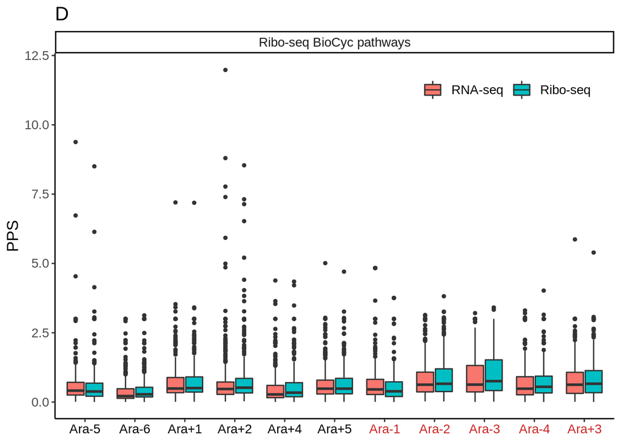

```r
ddf <- pps.df %>%
  filter(type == "actual")

ddf$seqtype <- factor(ddf$seqtype, levels = c("rna", "ribo"))

ddf$line <- factor(ddf$line, levels = mut.levels)

pd <- ddf %>%
  mutate(faclab = "Ribo-seq BioCyc pathways") %>%
  ggplot(., aes(line, pps, fill = seqtype))+
  geom_boxplot(outlier.size = 1)+
  theme_classic()+
  theme(text = element_text(size = 13),
        legend.position = c(.8, .9),
        axis.text.x = element_text(color = mut.colors),
        legend.background = element_blank(),
        legend.direction = "horizontal")+
  scale_fill_discrete(name = NULL, labels = c("RNA-seq", "Ribo-seq"))+
  labs(x = NULL,
       y = "PPS",
       title = "D")+
  facet_wrap(~faclab)

pd
```

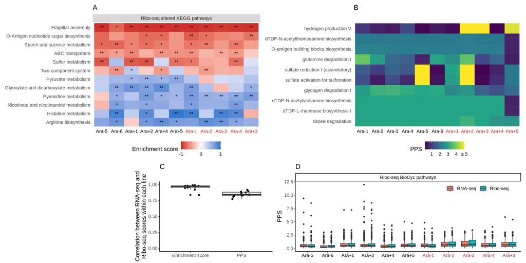

```r
ftop <- pa | pb

fbottom <- (plot_spacer() | pc | pd) + plot_layout(widths = c(.1, .3, .6))

(ff <- (ftop / fbottom) + plot_layout(heights = c(.6, .4)))
```

### Final figure

```r
ggsave(ff, filename = "../../figures/g_fig_s8.pdf", width = 16, height = 8, device = cairo_pdf)

ggsave(ff, filename = "../../figures/g_fig_s8.png", dpi = 300, width = 16, height = 8)
```